# Statistical Mechanics & Random Walks

From Microstates to Macroscopic Thermodynamics

## 1. The Random Walk

A **Random Walk** is fundamentally modeled as an *integer-time stochastic process*.

In this framework, each *X<sub>i</sub>* represents a single random step. The entire sequence maps out the trajectory of the system.

## 2. Statistical Ensembles

When modeling physical systems, the macroscopic constraints completely alter the rules governing the microscopic random walks.

| Ensemble | Fixed Quantities | Physical Setup | Mathematical Behavior |
| --- | --- | --- | --- |
| **Microcanonical** | N, V, E | Isolated box. | Unbiased random walk. Flat phase space. |
| **Canonical** | N, V, T | Heat bath + Force. | Biased random walk. Exponential steady state. |
| **Gibbs Canonical** | N, p/f, T | Constant force. | Volume/Displacement fluctuates. |
| **Grand Canonical** | μ, V, T | Open window. | Branching Markov process. Fluctuating N. |

## 3. The Canonical Pipeline

The physical mechanics connecting individual particles to continuous macrostates.

**1. Microstate:** A bounded environment where moving against gravity costs energy, and moving with gravity releases energy.

**2. Biased Walk:** A thermal kick might push a particle "up," but it has a much higher probability of falling "down."

**3. Markov Chain:** Transition probabilities are asymmetric, governed strictly by the Boltzmann Factor: \( P \propto e^{-\Delta E / k_B T} \)

**4. Ensemble:** We release \(10^{23}\) particles. Gravity pulls them down, but thermal noise (Temperature) violently spreads them out.

**5. Macrostate:** The cloud drifts until downward pull balances upward diffusion, forming a continuous **Exponential Distribution** (Fokker-Planck).

## 4. Markov Chains & Bounded Systems

To formalize this mathematically, we model the random walk as a **Markov Chain**. The defining characteristic of a Markov chain is *Memorylessness (The Markov Property)*: the next state depends **only** on the current state, completely ignoring the past sequence of events.

In 3D space (like a cubic lattice), an atom has 6 nearest neighbors, so it transitions to an adjacent state with equal probability in an isolated system.

Because a physical box is bounded (a finite-state Markov chain), the *Poincaré Recurrence Theorem* mathematically guarantees that if you wait long enough, the ensemble of particles will eventually return to its exact starting state.

## 5. 3D Lattice Gas Model (Python)

A Canonical Ensemble simulation with hard-core repulsion (Pauli Exclusion).

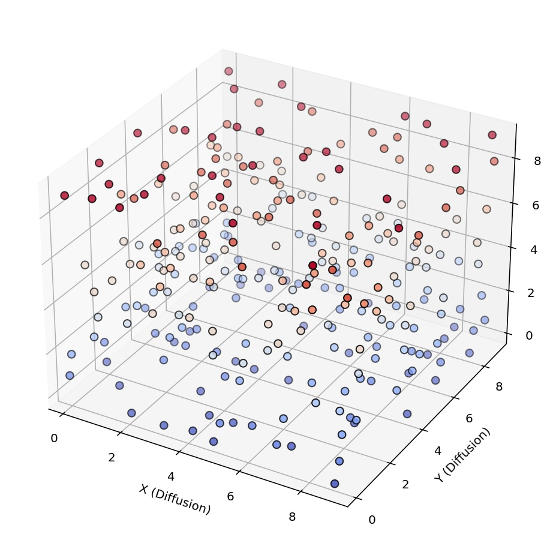

```python
import numpy as np
import matplotlib.pyplot as plt
import matplotlib.animation as animation

# --- 1. Simulation Parameters ---
N_PARTICLES = 300
GRID_SIZE = 10
TEMPERATURE = 1.5  # Low T = particles condense into a solid layer on the floor
GRAVITY = 1.0
STEPS_PER_FRAME = 5

# --- 2. Initialize Lattice ---
all_coords = np.array(np.meshgrid(np.arange(GRID_SIZE), np.arange(GRID_SIZE), np.arange(GRID_SIZE))).T.reshape(-1, 3)
np.random.shuffle(all_coords)
positions = all_coords[:N_PARTICLES].astype(int)

# --- 3. 3D Visualization Setup ---
fig = plt.figure(figsize=(8, 8))
ax = fig.add_subplot(111, projection='3d')

def get_display_positions(pos):
    jitter = np.random.uniform(-0.15, 0.15, size=pos.shape)
    return pos + jitter

disp = get_display_positions(positions)
sc = ax.scatter(disp[:,0], disp[:,1], disp[:,2], c=positions[:,2], cmap='coolwarm', s=40, edgecolors='k')

ax.set_xlim(-0.5, GRID_SIZE - 0.5)
ax.set_ylim(-0.5, GRID_SIZE - 0.5)
ax.set_zlim(-0.5, GRID_SIZE - 0.5)
ax.set_xlabel('X (Diffusion)')
ax.set_ylabel('Y (Diffusion)')
ax.set_zlabel('Z (Energy Level)')

# --- 4. The Physics Engine ---
def update(frame):
    global positions
    for _ in range(STEPS_PER_FRAME):
        idx = np.random.randint(N_PARTICLES)
        axis = np.random.randint(3)
        step = np.random.choice([-1, 1])

        proposed_pos = positions[idx].copy()
        proposed_pos[axis] += step

        if not (0 <= proposed_pos[axis] < GRID_SIZE): continue
        if np.any(np.all(positions == proposed_pos, axis=1)): continue

        dE = step * GRAVITY if axis == 2 else 0
        if dE <= 0 or np.random.random() < np.exp(-dE / TEMPERATURE):
            positions[idx] = proposed_pos

    disp = get_display_positions(positions)
    sc._offsets3d = (disp[:,0], disp[:,1], disp[:,2])
    sc.set_array(positions[:,2])
    ax.set_title(f'True 3D Lattice Gas\nT={TEMPERATURE}, g={GRAVITY}')
    return sc,

ani = animation.FuncAnimation(fig, update, frames=200, interval=30, blit=False)
plt.show()
```

## 6. The Simulation Code

```python
import random
import math
import matplotlib.pyplot as plt

# 1. The 3D State
class Location(object):
    def __init__(self, x, y, z):
        self.x = x
        self.y = y
        self.z = z

    def move(self, dx, dy, dz):
        new_z = max(0, self.z + dz)
        return Location(self.x + dx, self.y + dy, new_z)

    def getZ(self):
        return self.z

# 2. The Base Particle
class Walker(object):
    def __init__(self, name):
        self.name = name

# 3. The 3D Canonical Subclass
class CanonicalWalker3D(Walker):
    def __init__(self, name, temperature=5.0, gravity=0.2):
        super().__init__(name)
        self.T = temperature
        self.g = gravity

    def takeStep(self):
        axis = random.choice(['x', 'y', 'z'])
        dx, dy, dz = 0, 0, 0
        if axis == 'x': dx = random.choice([1, -1])
        elif axis == 'y': dy = random.choice([1, -1])
        else:
            proposed_dz = random.choice([1, -1])
            dE = self.g * proposed_dz
            if dE <= 0:
                dz = proposed_dz
            else:
                if random.random() < math.exp(-dE / self.T):
                    dz = proposed_dz
                else:
                    dz = 0
        return dx, dy, dz

# 4. The Environment
class Field(object):
    def __init__(self):
        self.walkers = {}
    def addWalker(self, walker, loc):
        self.walkers[walker] = loc
    def getLoc(self, walker):
        return self.walkers[walker]
    def moveWalker(self, walker):
        dx, dy, dz = walker.takeStep()
        currentLoc = self.walkers[walker]
        self.walkers[walker] = currentLoc.move(dx, dy, dz)

# 5. The Execution
def run_3d_ensemble_simulation(num_particles=1000, num_steps=500):
    heat_bath = Field()
    origin = Location(0, 0, 0)
    particles = []

    for i in range(num_particles):
        atom = CanonicalWalker3D(f"Atom_{i}", temperature=3.0, gravity=0.5)
        heat_bath.addWalker(atom, origin)
        particles.append(atom)

    for step in range(num_steps):
        for atom in particles:
            heat_bath.moveWalker(atom)

    final_heights = [heat_bath.getLoc(atom).getZ() for atom in particles]

    plt.figure(figsize=(8, 6))
    plt.hist(final_heights, bins=range(0, max(final_heights) + 2),
             color='skyblue', edgecolor='black', density=True, align='left')
    plt.title(f'Macroscopic Barometric Distribution\n(N={num_particles}, T=3.0, g=0.5)')
    plt.xlabel('Z-Height (Energy Level)')
    plt.ylabel('Density of Particles')
    plt.grid(True, alpha=0.3)
    plt.show()

if __name__ == '__main__':
    run_3d_ensemble_simulation()
```

## 7. The Macrostate & Diffusion

When we scale up from 1 particle to an ensemble of `N ≈ 10²³` particles, the *Law of Large Numbers* takes over. The chaotic, stochastic Markov chains perfectly average out.

∂*P* / ∂*t* = *D* ∇²*P*

The macroscopic probability density mathematically converges into a smooth Gaussian wave described by **Fick's Second Law of Diffusion** (above).

If a drift force (like gravity) is introduced, the system obeys the Fokker-Planck equation, ultimately settling into a deterministic thermodynamic equilibrium.

## 8. Simulation Result: Macroscopic Limit

Executing the Metropolis-Hastings simulation from Slide 6 yields the exact theoretical exponential decay (Barometric Formula).

[figure not shown]

## Bibliography & Sources

The foundational texts, papers, and lectures used to construct this presentation.

- **Books on Statistical Mechanics & Diffusion:**
  - [Mehran Kardar (2007). *Statistical Physics of Particles*. Cambridge University Press.](https://www.cambridge.org/core/books/statistical-physics-of-particles/68C5E7A2338A1AE3D39343FF1CD5E715)
  - [Mehran Kardar (2012). *Statistical Physics of Fields*. Cambridge University Press.](https://www.cambridge.org/core/books/statistical-physics-of-fields/7FF55CE7F157469FA5C30BA7071F1B18)
  - [John Crank (1975). *The Mathematics of Diffusion*. Oxford University Press.](https://global.oup.com/academic/product/the-mathematics-of-diffusion-9780198534112)
- **Academic Papers:**
  - [Ling Yang et al. (2022). *Diffusion Models: A Comprehensive Survey of Methods and Applications*. ArXiv.](https://arxiv.org/abs/2209.00796)
  - [*Diffusion Models Survey* (General Context).](https://arxiv.org/abs/2309.00000)
- **Lectures & Educational Materials:**
  - [MIT OpenCourseWare. *Lecture 5: Random Walks* (Prof. John Guttag).](https://ocw.mit.edu/courses/6-0002-introduction-to-computational-thinking-and-data-science-fall-2016/)
  - [MIT OpenCourseWare. *Lecture 21: Hypothesis Testing and Random Walks*.](https://ocw.mit.edu/courses/6-262-discrete-stochastic-processes-spring-2011/)
  - [Generative AI Animated. *Diffusion Models: DDPM*.](https://www.youtube.com/watch?v=EhndHhIvWWw)
  - [Generative AI Animated. *Score-based Diffusion Models*.](https://www.youtube.com/watch?v=lUljxdkolK8)